# 213070003_A01

## Question 1

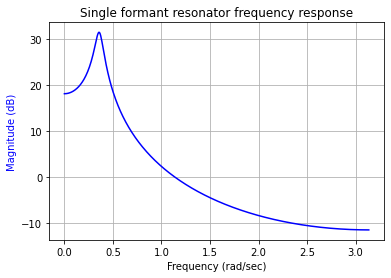

```python
'''
Question 1) Given the following specification for a single-formant resonator, obtain the transfer function of
the filter H(z) from the relation between resonance frequency / bandwidth, and the pole angle /
radius. Plot filter magnitude response (dB magnitude versus frequency) and impulse response.
F1 (formant) = 900 Hz
B1(bandwidth) = 200 Hz
Fs (sampling freq) = 16 kHz
'''
# Plotting the frequency magnitude response (in dB) of the single formant resonator
# Reference: https://docs.scipy.org/doc/scipy-0.13.0/reference/generated/scipy.signal.freqz.html

from scipy import signal    # Signal is used to find the frequency response points of the single formant resonator
import numpy as np          # numpy library is imported
import matplotlib.pyplot as plt    # matplotlib is used to plot figures
b = [1];                    # the numerator of the transfer function H(z) is assumed to be = 1
a = [1, -1.8, 0.924];       # coefficients of the denominator equation in z^-1
w, h = signal.freqz(b,a);   # w are the frequency points between [0,fs/2] at which frequency response magnitude is calculated
fig = plt.figure();         # declares the figure
plt.title('Single formant resonator frequency response'); # sets th title of the plot
plt.plot(w, 20*np.log10(np.abs(h)), 'b');             # plot the frequency magnitude (in dB) response
plt.ylabel('Magnitude (dB)', color='b');              # sets the y axis label
plt.xlabel('Frequency (rad/sec)');                    # sets the x axis label
plt.grid();                                           # shows the grid over the plot
plt.axis('tight');                                    # sets limits just large enough to show all data
plt.show();                                           # display the plot
```

**Question 1) Plotting the frequency magnitude response for given formant:**

1) The single formant is modelled by a 2 pole system. The formant frequency is given as F1 = 900 Hz and formant bandwidth B1 = 200 Hz at a sampling frequency = 16000 Hz.

2) Transfer function obtained is: H(z) = 1/(1-1.8z^-1+0.924z^-2);

3) Using the signal.freqz() function in scipy library we can find the magnitude response of the transfer function which is plotted in the above figure. We can observe a peak at w = 0.35 rad/sec which corresponds to F1 = 900 Hz.

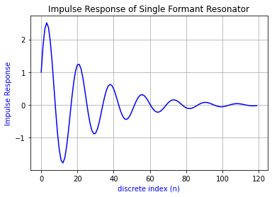

```python
# Plot the impulse response of the transfer function found above
y_buffer = np.zeros(2);                # declare a buffer to store previous two outputs and set initial conditions to zero
impulseRespSize = 120;                 # sets the number of impulse response samples to be calculated and plotted
impulseInp = np.zeros(impulseRespSize);# declare an numpy array to store the impulse input
impulseInp[0] = 1;                     # set the impulse input's first element to 1 (since an impulse is 1 at n=0 and zero elsewhere)
impulseResponse = np.zeros(impulseRespSize); # declare an numpy array to store the impulse response output
for i in range(impulseRespSize):
    impulseResponse[i] = impulseInp[i] + 1.8*y_buffer[0] - 0.924*y_buffer[1]; # the difference equation obtained from the transfer function
    y_buffer[0] = impulseResponse[i];  # stores the previous output in the buffer as the difference equation needs past 2 values in every iteration
    if i>0:
        y_buffer[1] = impulseResponse[i-1];
impResfig = plt.figure();              # delare a figure to show the impulse response plot
plt.title('Impulse Response of Single Formant Resonator');   # title of the plot
plt.plot(range(impulseRespSize), impulseResponse, 'b');      # plot the impulse response calculated above
plt.ylabel('Impulse Response', color='b');                   # set the y axis label
plt.xlabel('discrete index (n)', color = 'b');               # set the discrete time axis label
plt.grid();                                                  # display the grid of the plot
plt.axis('tight');                                           # sets limits just large enough to show all data
plt.show();                                                  # display the graph
```

**Question 1) Plotting the impulse response for given single formant resonator:**

1) The impulse response size is set to 120 samples because we can observe from the plot that it dies down after 120 samples.

2) In order to plot impulse response an input signal with impulse at n=0 and rest samples are = 0 is constructed in impulseInp.

3) Inside the for loop the impulse response is calculated by using a difference equaiton obtained from the transfer function obtained in the above block.

4) The difference equation need past two values of the output. These are stored in the y_buffer[] array.

5) The difference equation is as follows: y(n) = x(n) + 1.8y(n-1) - 0.924y(n-2).

6) The plot obtained is consistent with the damped sine wave which is obtained if we find out the impulse response of this system in the continuous time domain.

## Question 2

```python
def createInpWaveform(sampFreq, timeDuration, F0, numSamplesTriangle):
    numCycles = F0*timeDuration;                          # number of cycles for given source excitation frequency in 0.5 sec
    numSamplesPerCycle = sampFreq/F0;                     # number of samples per cycle = sampFreq/fundamental freq of source excitation = 100 in this case
    inpWaveform = np.zeros(int(sampFreq*timeDuration));   # input waveform declared as an array of zeros for 8000 samples so that it covers 0.5 sec time duration.
    triangle = np.zeros(numSamplesTriangle);              # declare a triangle array which stores the samples of a single triangle
    for i in range(numSamplesTriangle):                   # For loop creates 1 triangle comprising 5 samples
        if i<=2:
            triangle[i] = 0.5*i;
        elif i>2:
            triangle[i] = -0.5*i+2;
    impulsePos = np.zeros(int(F0*timeDuration));            # This array contains the positions of impulses in the input signal
    impulseWaveform = np.zeros(int(sampFreq*timeDuration)); # This array will store the output of convolution
    for i in range(int(F0*timeDuration)):                   # In tis for loop an impulse train is created which contains impulses placed at sample indices according to the given F0
      impulsePos[i] = round((sampFreq/F0)*i);
      impulseWaveform[round((sampFreq/F0)*i)] = 1;
    inpWaveform = signal.convolve(impulseWaveform,triangle,mode='same');  # To create an impulse train where impulses are approximated by narrow triangles we convolve the triangle in triangle[] array with impulseWaveform
    return inpWaveform                                      # Return the impulse train waveform where impulses are approximated by narrow triangles of 5 samples each.
```

1) The above function **createInpWaveform()** is used to create an impulse train waveform in which each impulse is approximated by a narrow triangle. In the impulse train waveform created in this function the triangular impulses repeat after every (sampFreq/F0) number of samples. This function is used in every code block after this to create the input impulse trains.

2) The impulses are placed at nearest rounded off values i.e. the integer multiples of sampFreq/F0 is not an integer if sampling frequency is not a multiple of F0 so in that case the impulses are placed at rounded off values.

3) For eg: F0 = 120 Hz and sampFreq = 16000. sampFreq/F0 = 133.33. So second impulse will be placed at round(133.33) = 133 rd index. Similarly, third impulse can be placed at round(133.33*2) = round(266.66) = 267 th index position and so on.

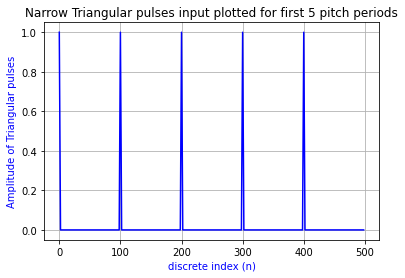

```python
'''
Question 2 Excite the above resonator (“filter”) with a periodic source excitation of F0 = 160 Hz. You can
approximate the source signal by a narrow-triangular pulse train. Compute the output of the
source-filter system over the duration of 0.5 second using the difference equation implementation
of the LTI system. Plot the time domain waveform over a few pitch periods so that you can
observe waveform characteristics. Play out the 0.5 sec duration sound and comment on the
sound quality.
'''

sampFreq = 16000;           # Sampling frequency as given in question
timeDuration = 0.5;         # time duration given in question
F0 = 160;                   # Fundamental frequency of source excitation
numSamplesTriangle = 5;     # assumed 5 samples per narrow triangular pulse
inpWaveform = createInpWaveform(sampFreq, timeDuration, F0, numSamplesTriangle);  # Creates the input waveform used as input to the difference equation implemented to obtain a 0.5 sec sound wave.
fig = plt.figure();                                                               # figure is declared
plt.title('Narrow Triangular pulses input plotted for first 5 pitch periods');    # title of the plot
plt.plot(range(int(sampFreq/F0)*5-1), inpWaveform[0:int(sampFreq/F0)*5-1], 'b');  # Plot only the first 5 pitch periods, this means there must be five impulses in the plot
plt.ylabel('Amplitude of Triangular pulses', color='b');    # set the y axis label
plt.xlabel('discrete index (n)',color='b');                 # set the discrete time axis label
plt.grid();                                                 # display the grid of the plot
plt.axis('tight');                                          # sets limits just large enough to show all data
plt.show();
```

**Question 2) Creating the source excitation**

1) The source signal is an impulse train where each impulse is approximated as a narrow triangle of width 5 samples. This signal is shown in above figure. Only the first five pitch periods of these pulses are plotted in the above figure.

2) The total length of the source signal is kept at 8000 samples as we want to generate a 0.5 sec duration audio signal.

3) The triangular impulses repeat after a period of N = 16000/160 = 100 samples.

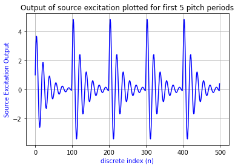

```python
'''
Plotting the time domain output waveform for Question 2 over five pitch periods
'''
numOutputSamples = sampFreq*timeDuration;       # total number of samples in output waveform
outputData = np.zeros(int(numOutputSamples));   # declare a numpy array for storing output data
y_buffer = np.zeros(2);                         # declare a buffer used to store previous outputs needed for difference equation implementation
for i in range(int(numOutputSamples)):
    outputData[i] = inpWaveform[i] + 1.8*y_buffer[0] - 0.924*y_buffer[1]; # the difference equation obtained from the transfer function
    y_buffer[0] = outputData[i];                                          # stores the previous output in the buffer as the difference equation needs past 2 values in every iteration
    if i>0:
        y_buffer[1] = outputData[i-1];
fig = plt.figure();
plt.title('Output of source excitation plotted for first 5 pitch periods');   # title of the plot
plt.plot(range(int(sampFreq/F0)*5), outputData[0:int(sampFreq/F0)*5], 'b');   # Plot only the first 5 pitch periods, this means there must be five impulses in the plot
plt.ylabel('Source Excitation Output', color='b');                            # set the y axis label
plt.xlabel('discrete index (n)',color='b');                                   # set the discrete time axis label
plt.grid();                                                                   # display the grid of the plot
plt.axis('tight');                                                            # sets limits just large enough to show all data
plt.show();
```

**Question 2) Computing the output of the source filter excitation**

1) I used the input waveform created earlier to produce a sound wave for a duration of 0.5 sec.

2) The output is computed using the difference equation method. The difference equation is same as question 1: y(n) = x(n) + 1.8y(n-1) - 0.924y(n-2).

3) The output time domain waveform for single formant resonator is plotted in the above plot for first five periods.

4) We can clearly observe the repetitions of the waveform in consecutive pitch periods.

5) I think that the first pitch period looks shorter in amplitude than consecutive pitch periods because of the boundry effects during the convolution of triangle with impulse train used to generate the source waveform.

6) The generated audio waveform is saved in a .wav file in the below code block in float32 format.

7) Only the source excitations at 800 Hz and 960 Hz lie within the formant bandwidth (i.e. between 800 Hz to 1000 Hz) hence the magnitudes of these components are amplified at output.

8) The pitch frequency in this question lies near the Female pitch range (i.e. 165 Hz to 255 Hz) which is reflected in the sound. The audio is not much harsh when compared with question 3(a).

```python
## To generate a .wav file for the created audio signal of a single formant

import scipy.io.wavfile
import IPython.display
outputData = np.asarray(outputData,dtype=np.float32);                   # Save the output data array in float32 format to create a .wav file
scipy.io.wavfile.write('Que2_Source_Excit.wav', sampFreq, outputData);  # create a .wav file
IPython.display.Audio('Que2_Source_Excit.wav')                          # Display the created audio file
```

[interactive chart not shown]

## Question 3(a)

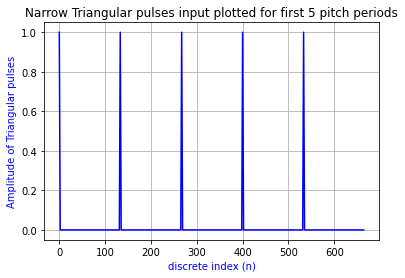

```python
'''
Question 3(a) Vary the parameters as indicated below; plot and comment on the differences in waveform and in
sound quality for the different parameter combinations.
F0 = 120 Hz, F1 = 300 Hz, B1 = 100 Hz
'''

# Generating the required narrow triangular pulse assuming that the narrow triangle has only 5 samples
sampFreq = 16000;                                           # Sampling frequency
timeDuration = 0.5;                                         # time duration
F0 = 120;                                                   # Fundamental frequency of source excitation
numSamplesTriangle = 5;                                     # assumed 5 samples per narrow triangular pulse
inpWaveform = createInpWaveform(sampFreq, timeDuration, F0, numSamplesTriangle);  # This function creates the source excitation with impulses approximated as triangular pulses
fig = plt.figure();                                         # figure is declared
plt.title('Narrow Triangular pulses input plotted for first 5 pitch periods');   # title of the plot
plt.plot(range(int(sampFreq/F0)*5), inpWaveform[0:int(sampFreq/F0)*5], 'b');     # Plot only the first 5 pitch periods
plt.ylabel('Amplitude of Triangular pulses', color='b');    # set the y axis label
plt.xlabel('discrete index (n)',color='b');                 # set the discrete time axis label
plt.grid();                                                 # display the grid of the plot
plt.axis('tight');                                          # sets limits just large enough to show all data
plt.show();
```

**Question 3(a)**

1) The pitch frequency has changed to F0 = 120 Hz. Due to this the pitch period changes to sampFreq/F0 = 16000/120 = 133.33 samples.

2) The plot of source excitation with F0 = 120 Hz is shown in above figure.

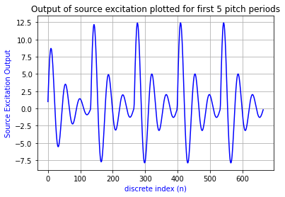

```python
'''
Plotting the time domain output waveform for Question 3(a) over five pitch periods
'''
numOutputSamples = sampFreq*timeDuration;       # total number of samples in output waveform
outputData = np.zeros(len(inpWaveform));        # declare a numpy array for storing output data
y_buffer = np.zeros(2);                         # declare a buffer used to store previous outputs needed for difference equation implementation
for i in range(len(outputData)):
    outputData[i] = inpWaveform[i] + 1.94*y_buffer[0] - 0.96*y_buffer[1]; # the difference equation obtained from the transfer function
    y_buffer[0] = outputData[i];                                          # stores the previous output in the buffer as the difference equation needs past 2 values in every iteration
    if i>0:
        y_buffer[1] = outputData[i-1];
fig = plt.figure();
plt.title('Output of source excitation plotted for first 5 pitch periods');   # title of the plot
plt.plot(range(int(sampFreq/F0)*5), outputData[0:int(sampFreq/F0)*5], 'b');   # Plot only the first 5 pitch periods, this means there must be five impulses in the plot
plt.ylabel('Source Excitation Output', color='b');                            # set the y axis label
plt.xlabel('discrete index (n)',color='b');                                   # set the discrete time axis label
plt.grid();                                                                   # display the grid of the plot
plt.axis('tight');                                                            # sets limits just large enough to show all data
plt.show();
```

**Question 3(a)**

1) The transfer function for F1 = 300 Hz, B1 = 100 Hz:

H(z) = 1/(1 - 1.94z^-1 + 0.96z^-2) and the difference equation is: y(n) = x(n) + 1.94y(n-1) - 0.96y(n-2).

2) This difference equation is implemented in the for loop in above code block and the output is plotted for first 5 pitch periods.

3) The following observations can be made from the above plot and the .wav file generated in below code block:

(a) Since the formant is centered at 300 Hz and spans from 250 Hz to 350 Hz and the pitch frequency is 120 Hz, none of the source excitations lie in this 250 Hz to 350 Hz range (240 Hz and 360 Hz both lie outside Formant frequency band).

(b) The pitch F0 = 120 Hz, the audio is rough when heard as compared to question 2. This pitch value lies in the range of male pitch frequencies.

(c) The waveform in Question 3(a) varies slowly as compared to that in Question 2 because the formant frequency F1 = 300 Hz is very less as compared to F1 = 900 Hz used in que 2. The gap between two consecutive cycles in the damping sinusiod is = 1/F1; so in que 3(a) the decay is slower.

```python
'''
Question 3(a) output audio
'''
outputData = np.asarray(outputData,dtype=np.float32);                      # Convert the outputData array into float32 format to create a .wav file
scipy.io.wavfile.write('Que3(a)_Source_Excit.wav', sampFreq, outputData);  # creates a .wav file
IPython.display.Audio('Que3(a)_Source_Excit.wav')                          # Display the created audio file
```

[interactive chart not shown]

## Question 3(b)

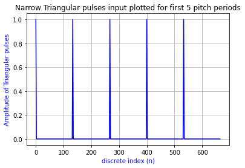

```python
'''
Question 3(b) Vary the parameters as indicated below; plot and comment on the differences in waveform and in
sound quality for the different parameter combinations.
F0 = 120 Hz, F1 = 1100 Hz, B1 = 200 Hz
'''
sampFreq = 16000;                                            # Sampling frequency
timeDuration = 0.5;                                          # time duration
F0 = 120;                                                    # Fundamental frequency of source excitation
numSamplesTriangle = 5;                                      # assumed 5 samples per narrow triangular pulse
inpWaveform = createInpWaveform(sampFreq, timeDuration, F0, numSamplesTriangle);  # This function creates the source excitation with impulses approximated as triangular pulses
fig = plt.figure();                                          # figure is declared
plt.title('Narrow Triangular pulses input plotted for first 5 pitch periods');    # title of the plot
plt.plot(range(int(sampFreq/F0)*5), inpWaveform[0:int(sampFreq/F0)*5], 'b');      # Plot only the first 5 pitch periods, this means there must be five impulses in the plot
plt.ylabel('Amplitude of Triangular pulses', color='b');    # set the y axis label
plt.xlabel('discrete index (n)',color='b');                 # set the discrete time axis label
plt.grid();                                                 # display the grid of the plot
plt.axis('tight');                                          # sets limits just large enough to show all data
plt.show();
```

**Question 3(b)**

1) The pitch frequency has changed to F0 = 120 Hz. Due to this the pitch period changes to sampFreq/F0 = 16000/120 = 133.33 samples.

2) The plot of source excitation with F0 = 120 Hz is shown in above figure.

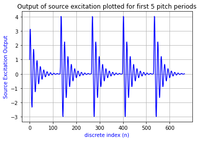

```python
'''
Plotting the time domain output waveform for Question 3(b) over five pitch periods
'''
numOutputSamples = sampFreq*timeDuration;       # total number of samples in output waveform
outputData = np.zeros(len(inpWaveform));        # declare a numpy array for storing output data
y_buffer = np.zeros(2);                         # declare a buffer used to store previous outputs needed for difference equation implementation
for i in range(len(outputData)):
    outputData[i] = inpWaveform[i] + 1.74*y_buffer[0] - 0.92*y_buffer[1]; # the difference equation obtained from the transfer function
    y_buffer[0] = outputData[i];                                          # stores the previous output in the buffer as the difference equation needs past 2 values in every iteration
    if i>0:
        y_buffer[1] = outputData[i-1];
fig = plt.figure();
plt.title('Output of source excitation plotted for first 5 pitch periods');   # title of the plot
plt.plot(range(int(sampFreq/F0)*5), outputData[0:int(sampFreq/F0)*5], 'b');   # Plot only the first 5 pitch periods, this means there must be five impulses in the plot
plt.ylabel('Source Excitation Output', color='b');                            # set the y axis label
plt.xlabel('discrete index (n)',color='b');                                   # set the discrete time axis label
plt.grid();                                                                   # display the grid of the plot
plt.axis('tight');                                                            # sets limits just large enough to show all data
plt.show();
```

**Question 3(b)**

1) The transfer function for F1 = 1100 Hz, B1 = 200 Hz:

H(z) = 1/(1 - 1.74z^-1 + 0.92z^-2) and the difference equation is: y(n) = x(n) + 1.74y(n-1) - 0.92y(n-2).

2) This difference equation is implemented in the for loop in above code block and the output is plotted for first 5 pitch periods.

3) The following observations can be made from the above plot and the .wav file generated in below code block:

(a) Since the formant is centered at 1100 Hz and spans from 1000 Hz to 1200 Hz and the pitch frequency is 120 Hz, some of the source excitations lie in this 1000 Hz to 1200 Hz range (1080 Hz and 1200 Hz both lie inside Formant frequency band). Hence frequency component of source excitation corresponding to 1080 Hz is amplified by the single formant resonator.

(b) The pitch F0 = 120 Hz, the audio is rough when heard as compared to question 2. This pitch value lies in the range of male pitch frequencies.

```python
'''
Question 3(b) output audio
'''
outputData = np.asarray(outputData,dtype=np.float32);                      # Convert the outputData array from float to int16 to create a .wav file
scipy.io.wavfile.write('Que3(b)_Source_Excit.wav', sampFreq, outputData);  # create a .wav file
IPython.display.Audio('Que3(b)_Source_Excit.wav')                          # Display the created audio file
```

[interactive chart not shown]

## Question 3(c)

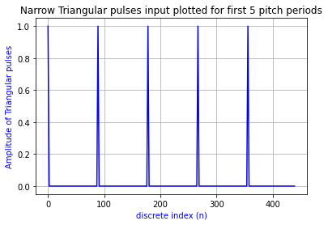

```python
'''
Question 3(c) Vary the parameters as indicated below; plot and comment on the differences in waveform and in
sound quality for the different parameter combinations.
F0 = 180 Hz, F1 = 300 Hz, B1 = 100 Hz
'''
sampFreq = 16000;                                                                 # Sampling frequency as given in question
timeDuration = 0.5;                                                               # time duration given in question
F0 = 180;                                                                         # Fundamental frequency of source excitation
numSamplesTriangle = 5;                                                           # assumed 5 samples per narrow triangular pulse
inpWaveform = createInpWaveform(sampFreq, timeDuration, F0, numSamplesTriangle);  # This function creates the source excitation with impulses approximated as triangular pulses
fig = plt.figure();   # figure is declared
plt.title('Narrow Triangular pulses input plotted for first 5 pitch periods');    # title of the plot
plt.plot(range(int(sampFreq/F0)*5), inpWaveform[0:int(sampFreq/F0)*5], 'b');      # Plot only the first 5 pitch periods, this means there must be five impulses in the plot
plt.ylabel('Amplitude of Triangular pulses', color='b');    # set the y axis label
plt.xlabel('discrete index (n)',color='b');                 # set the discrete time axis label
plt.grid();                                                 # display the grid of the plot
plt.axis('tight');                                          # sets limits just large enough to show all data
plt.show();
```

**Question 3(c)**

1) The pitch frequency has changed to F0 = 180 Hz. Due to this the pitch period changes to sampFreq/F0 = 16000/180 = 88.88 samples.

2) The plot of source excitation with F0 = 180 Hz is shown in above figure.

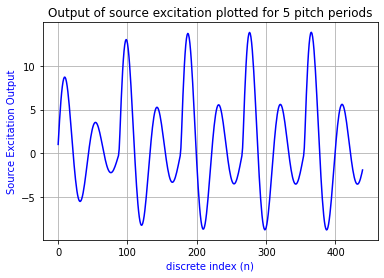

```python
'''
Plotting the time domain output waveform for Question 3(c) over five pitch periods
'''
numOutputSamples = sampFreq*timeDuration;                                     # total number of samples in output waveform
outputData = np.zeros(len(inpWaveform));                                      # declare a numpy array for storing output data
y_buffer = np.zeros(2);                                                       # declare a buffer used to store previous outputs needed for difference equation implementation
for i in range(len(outputData)):
    outputData[i] = inpWaveform[i] + 1.94*y_buffer[0] - 0.96*y_buffer[1];     # the difference equation obtained from the transfer function
    y_buffer[0] = outputData[i];                                              # stores the previous output in the buffer as the difference equation needs past 2 values in every iteration
    if i>0:
        y_buffer[1] = outputData[i-1];
fig = plt.figure();
plt.title('Output of source excitation plotted for 5 pitch periods');         # title of the plot
plt.plot(range(int(sampFreq/F0)*5), outputData[0:int(sampFreq/F0)*5], 'b');   # Plot only the 5 pitch periods
plt.ylabel('Source Excitation Output', color='b');                            # set the y axis label
plt.xlabel('discrete index (n)',color='b');                                   # set the discrete time axis label
plt.grid();                                                                   # display the grid of the plot
plt.axis('tight');                                                            # sets limits just large enough to show all data
plt.show();
```

**Question 3(c)**

1) The transfer function for F1 = 300 Hz, B1 = 100 Hz:

H(z) = 1/(1 - 1.94z^-1 + 0.96z^-2) and the difference equation is: y(n) = x(n) + 1.94y(n-1) - 0.96y(n-2).

2) This difference equation is implemented in the for loop in above code block and the output is plotted for first 5 pitch periods.

3) The following observations can be made from the above plot and the .wav file generated in below code block:

(a) Since the formant is centered at 300 Hz and spans from 250 Hz to 350 Hz and the pitch frequency is 180 Hz, nome of the source excitations lie in this 250 Hz to 350 Hz range (180 Hz and 360 Hz both lie outside Formant frequency band).

(b) The pitch F0 = 180 Hz, the audio is not rough when heard as compared to question 3(a) and 3(b). This pitch value lies in the range of female pitch frequencies.

(c) The waveform in Question 3(c) varies slowly as compared to that in Question 3(b) because the formant frequency F1 = 300 Hz is lower as compared to F1 = 1100 Hz used in que 3(b). The gap between two consecutive cycles in the damping sinusoid is = 1/F1; so in que 3(c) the decay is slow because F1 = 300 Hz is a smaller value.

```python
'''
Question 3(c) output audio
'''
outputData = np.asarray(outputData,dtype=np.float32);                      # Convert the outputData array from float to int16 to create a .wav file
scipy.io.wavfile.write('Que3(c)_Source_Excit.wav', sampFreq, outputData);  # create a .wav file
IPython.display.Audio('Que3(c)_Source_Excit.wav')                          # Display the created audio file
```

[interactive chart not shown]

## Question 4(a)

```python
def convOutput(inpWaveform,F0, sampFreq, timeDuration, prevOutput1_Coeff, prevOutput2_Coeff):
  numOutputSamples = sampFreq*timeDuration;       # total number of samples in output waveform
  outputData = np.zeros(len(inpWaveform));        # declare a numpy array for storing output data
  y_buffer = np.zeros(2);                         # declare a buffer used to store previous outputs needed for difference equation implementation
  for i in range(len(outputData)):
      # the difference equation obtained from the transfer function:
      outputData[i] = inpWaveform[i] + prevOutput1_Coeff*y_buffer[0] + prevOutput2_Coeff*y_buffer[1];
      y_buffer[0] = outputData[i]; # stores the previous output in the buffer as the difference equation needs past 2 values in every iteration
      if i>0:
          y_buffer[1] = outputData[i-1];  # Stores the second last sample in y_buffer[1]
  return outputData
```

**convOutput() function:**

This function takes an input waveform (in our case the source excitation waveform in which we have approximated the impulses by narrow triangles of width = 5) and the coefficients of a second order difference equation (in our case this is the formant) and gives the output waveform of same length as the input waveform.

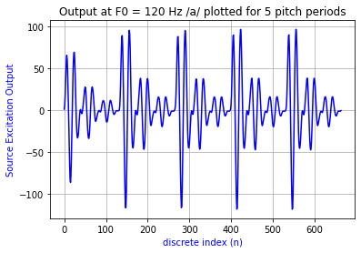

[interactive chart not shown]

```python
'''
Question 4 /a/ ) F0 = 120 Hz
B = 100 Hz
Duration = 0.5 sec
F1 = 730 Hz, F2 = 1090 Hz, F3 = 2440 Hz
'''
sampFreq = 16000;           # Sampling frequency as given in question
timeDuration = 0.5;         # time duration given in question
F0 = 120;                   # Fundamental frequency of source excitation
numSamplesTriangle = 5;     # assumed 5 samples per narrow triangular pulse
inpWaveform = createInpWaveform(sampFreq,timeDuration,F0,numSamplesTriangle); # creates input source excitation waveform
# input waveform created above is given to the function convOutput() which computes the output when the inout is passed through single formant resonator F1
outputData_F1 = convOutput(inpWaveform, F0, sampFreq, timeDuration, prevOutput1_Coeff = 1.88, prevOutput2_Coeff = -0.96);
# outputData_F1 created above is given to the function convOutput() which computes the output when the inout is passed through single formant resonator F2
outputData_F2 = convOutput(outputData_F1, F0, sampFreq, timeDuration, prevOutput1_Coeff = 1.78, prevOutput2_Coeff = -0.96);
# outputData_F2 created above is given to the function convOutput() which computes the output when the inout is passed through single formant resonator F3
outputData_F3 = convOutput(outputData_F2, F0, sampFreq, timeDuration, prevOutput1_Coeff = 1.127, prevOutput2_Coeff = -0.96);

fig = plt.figure();
plt.title('Output at F0 = 120 Hz /a/ plotted for 5 pitch periods');           # title of the plot
plt.plot(range(int(sampFreq/F0)*5), outputData_F3[0:int(sampFreq/F0)*5], 'b');# Plot only the 5 pitch periods
plt.ylabel('Source Excitation Output', color='b');                            # set the y axis label
plt.xlabel('discrete index (n)',color='b');                                   # set the discrete time axis label
plt.grid();                                                                   # display the grid of the plot
plt.axis('tight');                                                            # sets limits just large enough to show all data
plt.show();

outputData_F3 = np.asarray(outputData_F3,dtype=np.float32);                      # Convert the outputData array to float32 to create a .wav file
scipy.io.wavfile.write('Que4_a_1_Source_Excit.wav', sampFreq, outputData_F3);    # create a .wav file
IPython.display.Audio('Que4_a_1_Source_Excit.wav')                               # Display the created audio file
```

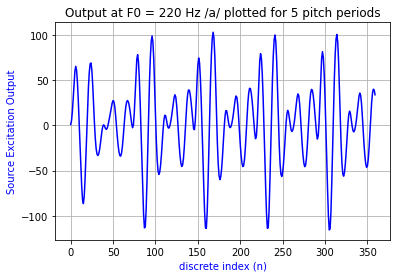

[interactive chart not shown]

```python
'''
Question 4 /a/ ) F0 = 220 Hz
B = 100 Hz
Duration = 0.5 sec
F1 = 730 Hz, F2 = 1090 Hz, F3 = 2440 Hz
'''

sampFreq = 16000;           # Sampling frequency as given in question
timeDuration = 0.5;         # time duration given in question
F0 = 220;                   # Fundamental frequency of source excitation
numSamplesTriangle = 5;     # assumed 5 samples per narrow triangular pulse
inpWaveform = createInpWaveform(sampFreq,timeDuration,F0,numSamplesTriangle); # creates input source excitation waveform
# input waveform created above is given to the function convOutput() which computes the output when the inout is passed through single formant resonator F1
outputData_F1 = convOutput(inpWaveform, F0, sampFreq, timeDuration, prevOutput1_Coeff = 1.88, prevOutput2_Coeff = -0.96);
# outputData_F1 created above is given to the function convOutput() which computes the output when the inout is passed through single formant resonator F2
outputData_F2 = convOutput(outputData_F1, F0, sampFreq, timeDuration, prevOutput1_Coeff = 1.78, prevOutput2_Coeff = -0.96);
# outputData_F2 created above is given to the function convOutput() which computes the output when the inout is passed through single formant resonator F3
outputData_F3 = convOutput(outputData_F2, F0, sampFreq, timeDuration, prevOutput1_Coeff = 1.127, prevOutput2_Coeff = -0.96);

fig = plt.figure();
plt.title('Output at F0 = 220 Hz /a/ plotted for 5 pitch periods');           # title of the plot
plt.plot(range(int(sampFreq/F0)*5), outputData_F3[0:int(sampFreq/F0)*5], 'b');# Plot only the 5 pitch periods
plt.ylabel('Source Excitation Output', color='b');                            # set the y axis label
plt.xlabel('discrete index (n)',color='b');                                   # set the discrete time axis label
plt.grid();                                                                   # display the grid of the plot
plt.axis('tight');                                                            # sets limits just large enough to show all data
plt.show();

outputData_F3 = np.asarray(outputData_F3,dtype=np.float32);                      # Convert the outputData array to float32 to create a .wav file
scipy.io.wavfile.write('Que4_a_2_Source_Excit.wav', sampFreq, outputData_F3);    # create a .wav file
IPython.display.Audio('Que4_a_2_Source_Excit.wav')                               # Display the created audio file
```

**Question 4(a) /a/ with F0 = 120 Hz and 220 Hz**

**Observations:**

1) Each of the formant can be treated as a second order system and the vowel can be considered as a cascade of three second order systems.

2) Each of the formants will have their own difference equation:

F1 = 730 Hz: y(n) = x(n) + 1.88y(n-1) -0.96y(n-2)

F2 = 1090 Hz: y(n) = x(n) + 1.78y(n-1) -0.96y(n-2)

3) First the input source excitation is creatd and given input to the first difference equation. Output of first difference equation is then input to the second difference equation. Output of second diff. eqn. is then given input to third difference equation.

4) The final sound generated is more shrill when pitch is 220 Hz and slightly rough when the pitch is 120 Hz.

5) When F0 = 120 Hz, the excitations corresponding to frequencies 720 Hz, 1080 Hz and 2400 Hz are amplified by F1, F2 and F3 respectively.

6) When F0 = 220 Hz, the excitations corresponding to frequencies 1100 Hz and 2420 Hz are amplified by F2 and F3 respectively because they fall in the frequency band of formants.

## Question 4(b)

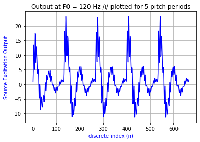

[interactive chart not shown]

```python
'''
Question 4 /i/ ) F0 = 120 Hz
B = 100 Hz
Duration = 0.5 sec
F1 = 270 Hz, F2 = 2290 Hz, F3 = 3010 Hz
'''
sampFreq = 16000;                                                             # Sampling frequency as given in question
timeDuration = 0.5;                                                           # time duration given in question
F0 = 120;                                                                     # Fundamental frequency of source excitation
numSamplesTriangle = 5;                                                       # assumed 5 samples per narrow triangular pulse
inpWaveform = createInpWaveform(sampFreq,timeDuration,F0,numSamplesTriangle); # Creates the input waveform
outputData_F1 = convOutput(inpWaveform, F0, sampFreq, timeDuration, prevOutput1_Coeff=1.948, prevOutput2_Coeff=-0.96);  # F1 output
outputData_F2 = convOutput(outputData_F1, F0, sampFreq, timeDuration, prevOutput1_Coeff=1.219, prevOutput2_Coeff=-0.96);# F2 output
outputData_F3 = convOutput(outputData_F2, F0, sampFreq, timeDuration, prevOutput1_Coeff=0.7429, prevOutput2_Coeff=-0.96); # F3 output

fig = plt.figure();
plt.title('Output at F0 = 120 Hz /i/ plotted for 5 pitch periods');           # title of the plot
plt.plot(range(int(sampFreq/F0)*5), outputData_F3[0:int(sampFreq/F0)*5], 'b');# Plot only the 5 pitch periods
plt.ylabel('Source Excitation Output', color='b');                            # set the y axis label
plt.xlabel('discrete index (n)',color='b');                                   # set the discrete time axis label
plt.grid();                                                                   # display the grid of the plot
plt.axis('tight');                                                            # sets limits just large enough to show all data
plt.show();

outputData_F3 = np.asarray(outputData_F3,dtype=np.float32);                    # Convert the outputData array to float32
scipy.io.wavfile.write('Que4_i_1_Source_Excit.wav', sampFreq, outputData_F3);  # create a .wav file
IPython.display.Audio('Que4_i_1_Source_Excit.wav')                             # Display the created audio file
```

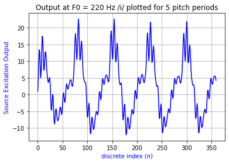

[interactive chart not shown]

```python
'''
Question 4 /i/ ) F0 = 220 Hz
B = 100 Hz
Duration = 0.5 sec
F1 = 270 Hz, F2 = 2290 Hz, F3 = 3010 Hz
'''
sampFreq = 16000;           # Sampling frequency as given in question
timeDuration = 0.5;         # time duration given in question
F0 = 220;                   # Fundamental frequency of source excitation
numSamplesTriangle = 5;     # assumed 5 samples per narrow triangular pulse
inpWaveform = createInpWaveform(sampFreq,timeDuration,F0,numSamplesTriangle); # Creates the input waveform
outputData_F1 = convOutput(inpWaveform, F0, sampFreq, timeDuration, prevOutput1_Coeff=1.948, prevOutput2_Coeff=-0.96);    # F1 output
outputData_F2 = convOutput(outputData_F1, F0, sampFreq, timeDuration, prevOutput1_Coeff=1.219, prevOutput2_Coeff=-0.96);  # F2 output
outputData_F3 = convOutput(outputData_F2, F0, sampFreq, timeDuration, prevOutput1_Coeff=0.7429, prevOutput2_Coeff=-0.96); # F3 output

fig = plt.figure();
plt.title('Output at F0 = 220 Hz /i/ plotted for 5 pitch periods');           # title of the plot
plt.plot(range(int(sampFreq/F0)*5), outputData_F3[0:int(sampFreq/F0)*5], 'b');# Plot only the 5 pitch periods
plt.ylabel('Source Excitation Output', color='b');                            # set the y axis label
plt.xlabel('discrete index (n)',color='b');                                   # set the discrete time axis label
plt.grid();                                                                   # display the grid of the plot
plt.axis('tight');                                                            # sets limits just large enough to show all data
plt.show();

outputData_F3 = np.asarray(outputData_F3,dtype=np.float32);                   # Convert the outputData array from float to int16 to create a .wav file
scipy.io.wavfile.write('Que4_i_2_Source_Excit.wav', sampFreq, outputData_F3); # Create a .wav file
IPython.display.Audio('Que4_i_2_Source_Excit.wav')                            # Display the created audio file
```

**Question 4(b) /i/ with F0 = 120 Hz and 220 Hz**

**Observations:**

1) Each of the formant can be treated as a second order system and the vowel can be considered as a cascade of three second order systems.

2) Each of the formants will have their own difference equation:

F1 = 270 Hz: y(n) = x(n) + 1.948y(n-1) - 0.96y(n-2)

F2 = 2290 Hz: y(n) = x(n) + 1.219y(n-1) - 0.96y(n-2)

F3 = 3010 Hz: y(n) = x(n) + 0.7429y(n-1) - 0.96y(n-2)

3) First the input source excitation is creatd and given input to the first difference equation. Output of first difference equation is then input to the second difference equation. Output of second diff. eqn. is then given input to third difference equation.

4) The final sound generated is more shrill when pitch is 220 Hz and slightly rough when the pitch is 120 Hz.

5) When F0 = 120 Hz, the excitations corresponding to frequencies 240 Hz, 2280 Hz and 3000 Hz are amplified by F1, F2 and F3 respectively.

6) When F0 = 220 Hz, the excitations corresponding to frequencies 220 Hz is amplified by F1 because it fall in the frequency band of formant F1.

## Question 4(c)

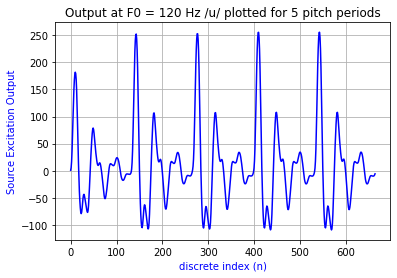

[interactive chart not shown]

```python
'''
Question 4 /u/ ) F0 = 120 Hz
B = 100 Hz
Duration = 0.5 sec
F1 = 300 Hz, F2 = 870 Hz, F3 = 2240 Hz
'''
sampFreq = 16000;                       # Sampling frequency as given in question
timeDuration = 0.5;                     # time duration given in question
F0 = 120;                               # Fundamental frequency of source excitation
numSamplesTriangle = 5;
inpWaveform = createInpWaveform(sampFreq, timeDuration, F0, numSamplesTriangle);  # input waveform is generated
outputData_F1 = convOutput(inpWaveform, F0, sampFreq, timeDuration, prevOutput1_Coeff=1.94, prevOutput2_Coeff=-0.96);     # F1 output
outputData_F2 = convOutput(outputData_F1, F0, sampFreq, timeDuration, prevOutput1_Coeff=1.847, prevOutput2_Coeff=-0.96);  # F2 output
outputData_F3 = convOutput(outputData_F2, F0, sampFreq, timeDuration, prevOutput1_Coeff=1.2494, prevOutput2_Coeff=-0.96); # F3 output

fig = plt.figure();
plt.title('Output at F0 = 120 Hz /u/ plotted for 5 pitch periods');           # title of the plot
plt.plot(range(int(sampFreq/F0)*5), outputData_F3[0:int(sampFreq/F0)*5], 'b');# Plot only the 5 pitch periods
plt.ylabel('Source Excitation Output', color='b');                            # set the y axis label
plt.xlabel('discrete index (n)',color='b');                                   # set the discrete time axis label
plt.grid();                                                                   # display the grid of the plot
plt.axis('tight');                                                            # sets limits just large enough to show all data
plt.show();

outputData_F3 = np.asarray(outputData_F3,dtype=np.float32);                        # Convert the outputData array from float to int16 to create a .wav file
scipy.io.wavfile.write('Que4_u_1_Source_Excit.wav', sampFreq, outputData_F3);      # Create a .wav file
IPython.display.Audio('Que4_u_1_Source_Excit.wav')                                 # Display the created audio file
```

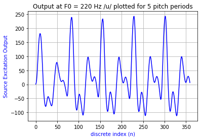

[interactive chart not shown]

```python
'''
Question 4 /u/ ) F0 = 220 Hz
B = 100 Hz
Duration = 0.5 sec
F1 = 300 Hz, F2 = 870 Hz, F3 = 2240 Hz
'''
sampFreq = 16000;                 # Sampling frequency as given in question
timeDuration = 0.5;               # time duration given in question
F0 = 220;                         # Fundamental frequency of source excitation
numSamplesTriangle = 5;           # assumed 5 samples per narrow triangular pulse
inpWaveform = createInpWaveform(sampFreq, timeDuration, F0, numSamplesTriangle);  # input waveform is generated
outputData_F1 = convOutput(inpWaveform, F0, sampFreq, timeDuration, prevOutput1_Coeff=1.94, prevOutput2_Coeff=-0.96);    # F1 output
outputData_F2 = convOutput(outputData_F1, F0, sampFreq, timeDuration, prevOutput1_Coeff=1.847, prevOutput2_Coeff=-0.96); # F2 output
outputData_F3 = convOutput(outputData_F2, F0, sampFreq, timeDuration, prevOutput1_Coeff=1.2494, prevOutput2_Coeff=-0.96);# F3 output

fig = plt.figure();
plt.title('Output at F0 = 220 Hz /u/ plotted for 5 pitch periods');               # title of the plot
plt.plot(range(int(sampFreq/F0)*5), outputData_F3[0:int(sampFreq/F0)*5], 'b');    # Plot only the 5 pitch periods
plt.ylabel('Source Excitation Output', color='b');                                # set the y axis label
plt.xlabel('discrete index (n)',color='b');                                       # set the discrete time axis label
plt.grid();                                                                       # display the grid of the plot
plt.axis('tight');                                                                # sets limits just large enough to show all data
plt.show();

outputData_F3 = np.asarray(outputData_F3,dtype=np.float32);                      # Convert the outputData_F3 to float32 to create a .wav file
scipy.io.wavfile.write('Que4_u_2_Source_Excit.wav', sampFreq, outputData_F3);    # Create a .wav file
IPython.display.Audio('Que4_u_2_Source_Excit.wav')                               # Display the created audio file
```

**Observations:**

1) Each of the formant can be treated as a second order system and the vowel can be considered as a cascade of three second order systems.

2) Each of the formants will have their own difference equation:

F1 = 300 Hz: y(n) = x(n) + 1.94y(n-1) - 0.96y(n-2)

F2 = 870 Hz: y(n) = x(n) + 1.847y(n-1) - 0.96y(n-2)

3) First the input source excitation is creatd and given input to the first difference equation. Output of first difference equation is then input to the second difference equation. Output of second diff. eqn. is then given input to third difference equation.

4) The final sound generated is more shrill when pitch is 220 Hz and slightly rough when the pitch is 120 Hz.

5) When F0 = 120 Hz, the excitations corresponding to frequencies 840 Hz and 2280 Hz are amplified by F2 and F3 respectively.

6) When F0 = 220 Hz, the excitations corresponding to frequencies 880 Hz and 2200 Hz are amplified by F2 and F3 respectively because they fall in the frequency band of formant F2 and F3.